# Estimating concordance signatures

Alexander J. McNeil and Johanna Neslehova

2020-11-11

### Estimating concordance signature from data

Consider a Gaussian copula with the following correlation matrix.

```r
P <- copula::p2P((1:10) / 11)
P
```

```
#>            [,1]       [,2]      [,3]      [,4]      [,5]
#> [1,] 1.00000000 0.09090909 0.1818182 0.2727273 0.3636364
#> [2,] 0.09090909 1.00000000 0.4545455 0.5454545 0.6363636
#> [3,] 0.18181818 0.45454545 1.0000000 0.7272727 0.8181818
#> [4,] 0.27272727 0.54545455 0.7272727 1.0000000 0.9090909
#> [5,] 0.36363636 0.63636364 0.8181818 0.9090909 1.0000000
```

This is the true concordance signature.

```r
consignature(P)
```

```
#>     empty     {1,2}     {1,3}     {1,4}     {1,5}     {2,3}     {2,4}     {2,5}
#> 1.0000000 0.5289773 0.5581982 0.5879257 0.6184649 0.6501983 0.6836430 0.7195622
#>     {3,4}     {3,5}     {4,5} {1,2,3,4} {1,2,3,5} {1,2,4,5} {1,3,4,5} {2,3,4,5}
#> 0.7592125 0.8050178 0.8632223 0.3248812 0.3513279 0.3839727 0.4382830 0.5313977
```

We can generate some data from the copula and estimate the signature from the data.

```r
set.seed(17)
data <- rmvnorm(1000, sigma = P)
kappa <- estsignature(data)
kappa
```

```
#>     empty     {1,2}     {1,3}     {1,4}     {1,5}     {2,3}     {2,4}     {2,5}
#> 1.0000000 0.5422222 0.5666486 0.6053273 0.6274074 0.6566827 0.6829049 0.7254254
#>     {3,4}     {3,5}     {4,5} {1,2,3,4} {1,2,3,5} {1,2,4,5} {1,3,4,5} {2,3,4,5}
#> 0.7597317 0.8043303 0.8665646 0.3390791 0.3651932 0.3992573 0.4505826 0.5356136
```

Note how this method gives the same Kendall’s tau matrix as the standard estimator. This is only true in the absence of ties.

```r
tau <- c((2*kappa - 1)[2 : 11], (8*kappa - 1)[12 : 16]/7)
tau
```

```
#>      {1,2}      {1,3}      {1,4}      {1,5}      {2,3}      {2,4}      {2,5}
#> 0.08444444 0.13329730 0.21065465 0.25481481 0.31336537 0.36580981 0.45085085
#>      {3,4}      {3,5}      {4,5}  {1,2,3,4}  {1,2,3,5}  {1,2,4,5}  {1,3,4,5}
#> 0.51946346 0.60866066 0.73312913 0.24466180 0.27450651 0.31343687 0.37209438
#>  {2,3,4,5}
#> 0.46927270
```

```r
cor(data, method = "kendall")
```

```
#>            [,1]       [,2]      [,3]      [,4]      [,5]
#> [1,] 1.00000000 0.08444444 0.1332973 0.2106547 0.2548148
#> [2,] 0.08444444 1.00000000 0.3133654 0.3658098 0.4508509
#> [3,] 0.13329730 0.31336537 1.0000000 0.5194635 0.6086607
#> [4,] 0.21065465 0.36580981 0.5194635 1.0000000 0.7331291
#> [5,] 0.25481481 0.45085085 0.6086607 0.7331291 1.0000000
```

### Estimating concordance signature for real data

In the next example we take some cryptocurrency data. The dataset is 4-dimensional and contains the prices of Bitcoin, Ethereum, Litecoin and Ripple is US dollars. We look at the daily log-returns for the year 2017.

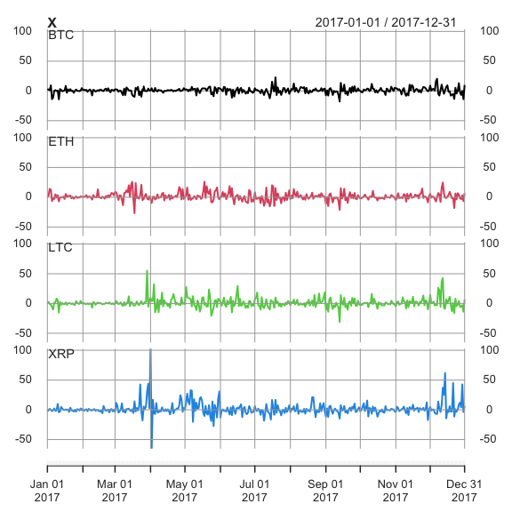

```r
data(crypto)
data <- crypto['2016-12-31/2017-12-31']
X <- (diff(log(data))[-1]) * 100
plot(X, multi.panel=TRUE)
```

Now we estimate the concordance signature and find an extremal mixture copula that matches the estimated signature.

```r
fullsig <- estsignature(as.matrix(X))
fullsig
```

```
#>     empty     {1,2}     {1,3}     {1,4}     {2,3}     {2,4}     {3,4} {1,2,3,4}
#> 1.0000000 0.6391164 0.6663405 0.5978323 0.6806187 0.6299789 0.6610718 0.3641954
```

```r
findextremal(fullsig)
```

```
#>  {0,0,0,0}  {0,0,0,1}  {0,0,1,0}  {0,0,1,1}  {0,1,0,0}  {0,1,0,1}  {0,1,1,0}
#> 0.36419539 0.12884239 0.06926840 0.07681018 0.09842692 0.07487581 0.06594159
#>  {0,1,1,1}
#> 0.12163932
```

### Inferring Kendall correlations for missing variables

Let us suppose that we had no information about the fourth cryptocurrency, Ripple, and had to infer possible rank correlation values from knowledge of the other three.

We want to find the concordance signatures that are consistent with our existing knowledge. We first find the vertices of the polytope of possible weight vectors.

```r
sig_3missing <- fullsig[c("empty", "{1,2}", "{1,3}", "{2,3}")]
sig_3missing
```

```
#>     empty     {1,2}     {1,3}     {2,3}
#> 1.0000000 0.6391164 0.6663405 0.6806187
```

```r
d <- 4
vert <- findpolytope(sig_3missing, d = d)
nvert <- dim(vert)[1]
vert
```

```
#>     {0,0,0,0} {0,0,0,1} {0,0,1,0} {0,0,1,1} {0,1,0,0} {0,1,0,1} {0,1,1,0}
#> v1  0.4930378 0.0000000 0.0000000 0.1460786 0.0000000 0.1733027 0.0000000
#> v2  0.4930378 0.0000000 0.0000000 0.1460786 0.0000000 0.1733027 0.1875809
#> v3  0.4930378 0.0000000 0.0000000 0.1460786 0.1733027 0.0000000 0.0000000
#> v4  0.4930378 0.0000000 0.0000000 0.1460786 0.1733027 0.0000000 0.1875809
#> v5  0.4930378 0.0000000 0.1460786 0.0000000 0.1733027 0.0000000 0.0000000
#> v6  0.4930378 0.0000000 0.1460786 0.0000000 0.1733027 0.0000000 0.1875809
#> v7  0.4930378 0.0000000 0.1460786 0.0000000 0.0000000 0.1733027 0.1875809
#> v8  0.4930378 0.0000000 0.1460786 0.0000000 0.0000000 0.1733027 0.0000000
#> v9  0.0000000 0.4930378 0.1460786 0.0000000 0.1733027 0.0000000 0.1875809
#> v10 0.0000000 0.4930378 0.1460786 0.0000000 0.1733027 0.0000000 0.0000000
#> v11 0.0000000 0.4930378 0.1460786 0.0000000 0.0000000 0.1733027 0.1875809
#> v12 0.0000000 0.4930378 0.1460786 0.0000000 0.0000000 0.1733027 0.0000000
#> v13 0.0000000 0.4930378 0.0000000 0.1460786 0.1733027 0.0000000 0.1875809
#> v14 0.0000000 0.4930378 0.0000000 0.1460786 0.1733027 0.0000000 0.0000000
#> v15 0.0000000 0.4930378 0.0000000 0.1460786 0.0000000 0.1733027 0.1875809
#> v16 0.0000000 0.4930378 0.0000000 0.1460786 0.0000000 0.1733027 0.0000000
#>     {0,1,1,1}
#> v1  0.1875809
#> v2  0.0000000
#> v3  0.1875809
#> v4  0.0000000
#> v5  0.1875809
#> v6  0.0000000
#> v7  0.0000000
#> v8  0.1875809
#> v9  0.0000000
#> v10 0.1875809
#> v11 0.0000000
#> v12 0.1875809
#> v13 0.0000000
#> v14 0.1875809
#> v15 0.0000000
#> v16 0.1875809
```

We can check that each of these vertices is a concordance signature that matches the given values of Kendall’s tau. Here we consider the final vertex.

```r
output <- vector("list", length = nvert)
for (i in 1:nvert)
  output[[i]] <- extmixcorr(vert[i,])
output[[nvert]]
```

```
#>            [,1]       [,2]       [,3]       [,4]
#> [1,]  1.0000000  0.2782327  0.3326810 -1.0000000
#> [2,]  0.2782327  1.0000000  0.3612374 -0.2782327
#> [3,]  0.3326810  0.3612374  1.0000000 -0.3326810
#> [4,] -1.0000000 -0.2782327 -0.3326810  1.0000000
```

```r
2 * sig_3missing - 1
```

```
#>     empty     {1,2}     {1,3}     {2,3}
#> 1.0000000 0.2782327 0.3326810 0.3612374
```

```r
kappas <- Amatrix(d) %*% t(vert)
kappas3 <- t(kappas[c("{1,4}", "{2,4}", "{3,4}"), ])
taus3 <- 2*kappas3 -1
taus3_hull <- taus3[convexHull(taus3)$pts[,"vtx"],]
taus3_hull <- round(taus3_hull, 8)
plot3d(taus3_hull, plot=FALSE)
plotHull3D(taus3_hull, drawPoints = TRUE, drawLines=FALSE, drawPolygons=TRUE)
```

[interactive chart not shown]

If an expert gave his opinion on the values of the Kendall rank correlations between Ripple and the other cryptocurrencies, the resulting point would have to lie within this 3-dimensional convex polytope.

```r
sig_2missing <- fullsig[c("empty", "{1,2}", "{1,3}", "{1,4}", "{2,3}")]
sig_2missing
```

```
#>     empty     {1,2}     {1,3}     {1,4}     {2,3}
#> 1.0000000 0.6391164 0.6663405 0.5978323 0.6806187
```

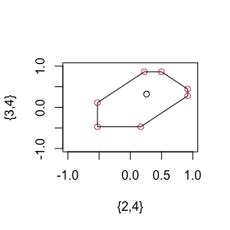

```r
vert <- findpolytope(sig_2missing, d = d)
nvert <- dim(vert)[1]
kappas <- Amatrix(d) %*% t(vert)
kappas2 <- t(kappas[c("{2,4}", "{3,4}"), ])
taus2 <- 2*kappas2 -1
taus2_hull <- taus2[convexHull(taus2)$pts[,"vtx"],]
plot(taus2_hull, col = 2, xlim = c(-1,1), ylim = c(-1,1))
lines(rbind(taus2_hull, taus2_hull[1,]))
points(2*fullsig["{2,4}"]-1, 2*fullsig["{3,4}"]-1)
```

We can add this set to our 3-dimensional plot.

```r
component14 <- rep(as.numeric(2*fullsig["{1,4}"]-1), dim(taus2_hull)[1])
plane_pts <- cbind(component14, taus2_hull)
dimnames(plane_pts)[[2]] <- c("{1,4}", "{2,4}", "{3,4}")
plotHull3D(plane_pts)
```

[interactive chart not shown]